# Exploratory Analysis of Women’s Health Microbial Signatures

General Landscape Analysis (BugSigDB)

Sally Karimi Kinyua

# Introduction

This vignette demonstrates an exploratory analysis of microbial signatures associated with women’s health conditions using data obtained from BugSigDB and functions provided by the bugSigSimple package. This is the **General** analysis — a broad landscape view across many women’s-health-related conditions (breast cancer, cervical cancer, endometriosis, pregnancy/maternal-child topics, and other reproductive/gynecological conditions). Four focused sub-analyses (Cervical Cancer, Breast Cancer, Endometriosis, and Pregnancy/Maternal-Child) build on this General analysis with condition-specific rigor.

# Analysis objectives

1. Downloading the data from BugSigDB
2. Filtering the data to select women’s-health-related signatures and remove duplicates
3. Description of the studies (body site, sequencing platform, publication year)
4. Description of the taxa
5. Core consensus signature and basic statistical tests
6. Monte Carlo simulation to calculate critical N
7. Heatmaps and dendrograms

# Environment note

**Before running this vignette**, confirm your Bioconductor infrastructure loads cleanly. If `library(S4Vectors)` (or any of its dependents) fails with an error like *“package could not be loaded”* or *“reached elapsed time limit”*, reinstall it fresh in an otherwise-idle R session before proceeding:

```r
remove.packages("S4Vectors")
BiocManager::install("S4Vectors", update = FALSE, force = TRUE)
# Restart R (Session > Restart R) before continuing
```

# Making sure packages are installed

```r
if (!require("BiocManager", quietly = TRUE))
    install.packages("BiocManager")
BiocManager::install(c("devtools", "tidyverse", "kableExtra"))
BiocManager::install(c("waldronlab/bugSigSimple", "waldronlab/BugSigDBStats", "waldronlab/bugsigdbr"))
```

# Download BugSigDB data

```r
full.dat <- bugsigdbr::importBugSigDB(cache = FALSE)

dim(full.dat)
```

```
## [1] 5520   50
```

# Remove empty signatures

```r
ind1 <- lengths(full.dat[["MetaPhlAn taxon names"]]) > 0
ind2 <- lengths(full.dat[["NCBI Taxonomy IDs"]]) > 0

dat <- full.dat[ind1 & ind2, ]

dim(dat)
```

```
## [1] 5520   50
```

# Select women’s-health-related signatures

```r
womens_health_terms <- c(
  # Breast
  "Breast cancer", "Breast cancer stage", "Breast carcinoma", "HER2 Positive Breast Carcinoma",
  # Cervical
  "Cervical cancer", "Cervical cerclage", "Cervical glandular intraepithelial neoplasia",
  "Cervical glandular intraepithelial neoplasia,Cervical cancer",
  "Cervical glandular intraepithelial neoplasia,Human papilloma virus infection",
  "Cervix erosion", "Human papilloma virus infection", "Human papilloma virus infection,Age",
  "Human papilloma virus infection,Cervical cancer",
  "Human papilloma virus infection,Cervical glandular intraepithelial neoplasia",
  "Chlamydophila infectious disease,Human papilloma virus infection",
  # Endometriosis
  "Endometriosis", "Adenomyosis", "Adenomyosis,Endometriosis",
  # Pregnancy / maternal-child
  "Pregnancy", "Gestational age", "Gestational diabetes", "Vaginal microbiome measurement",
  "Premature birth", "Spontaneous preterm birth", "Preterm premature rupture of the membranes",
  "Birth weight", "Birth measurement", "HIV mother to child transmission",
  "Neonatal death", "Neonatal jaundice", "Postnatal growth retardation",
  "Necrotizing enterocolitis", "Breastfeeding duration", "Breastfeeding duration,Transport",
  "Maternal milk", "Cesarean section", "Delivery method",
  # Broader women's health
  "Ovarian cancer", "Polycystic ovary syndrome", "Menopause", "Postmenopausal",
  "Postmenopausal osteoporosis", "Acquired primary ovarian failure", "Endometrial cancer",
  "Bacterial vaginosis", "Vaginitis", "Vulvovaginitis", "Vulvovaginal candidiasis",
  "Gonorrhea", "Chlamydia trachomatis", "Chlamydia trachomatis infectious disease",
  "Genital neoplasm, femaale", "Age at menarche", "Hormone replacement therapy", "Parous","Rosacea", "Ehlers-Danlos syndrome"
)


womens_health_dat <- dat %>%
  filter(Condition %in% womens_health_terms)

dim(womens_health_dat)
```

```
## [1] 580  50
```

```r
womens_health_dat %>%
  count(Condition, sort = TRUE) %>%
  knitr::kable()
```

| Condition | n |
| --- | --- |
| Human papilloma virus infection | 74 |
| Cervical glandular intraepithelial neoplasia | 55 |
| Gestational diabetes | 45 |
| Cesarean section | 42 |
| Endometriosis | 42 |
| Spontaneous preterm birth | 32 |
| Breast cancer | 26 |
| Polycystic ovary syndrome | 25 |
| Vaginal microbiome measurement | 23 |
| Breastfeeding duration | 22 |
| Delivery method | 19 |
| Cervical cancer | 18 |
| HIV mother to child transmission | 18 |
| Premature birth | 13 |
| Chlamydia trachomatis | 9 |
| Breast carcinoma | 8 |
| Menopause | 6 |
| Ovarian cancer | 6 |
| Pregnancy | 6 |
| Gonorrhea | 5 |
| Human papilloma virus infection,Cervical glandular intraepithelial neoplasia | 5 |
| Vulvovaginitis | 5 |
| Bacterial vaginosis | 4 |
| Birth measurement | 4 |
| Gestational age | 4 |
| Neonatal jaundice | 4 |
| Preterm premature rupture of the membranes | 4 |
| Adenomyosis,Endometriosis | 3 |
| Chlamydia trachomatis infectious disease | 3 |
| Necrotizing enterocolitis | 3 |
| Rosacea | 3 |
| Acquired primary ovarian failure | 2 |
| Adenomyosis | 2 |
| Age at menarche | 2 |
| Breast cancer stage | 2 |
| Breastfeeding duration,Transport | 2 |
| Cervical cerclage | 2 |
| Cervical glandular intraepithelial neoplasia,Cervical cancer | 2 |
| Cervix erosion | 2 |
| Chlamydophila infectious disease,Human papilloma virus infection | 2 |
| Endometrial cancer | 2 |
| HER2 Positive Breast Carcinoma | 2 |
| Hormone replacement therapy | 2 |
| Human papilloma virus infection,Age | 2 |
| Human papilloma virus infection,Cervical cancer | 2 |
| Maternal milk | 2 |
| Neonatal death | 2 |
| Postmenopausal osteoporosis | 2 |
| Postnatal growth retardation | 2 |
| Vaginitis | 2 |
| Vulvovaginal candidiasis | 2 |
| Birth weight | 1 |
| Cervical glandular intraepithelial neoplasia,Human papilloma virus infection | 1 |
| Parous | 1 |
| Postmenopausal | 1 |

Unlike the other Summer Projects analysis, no single body site captures the relevant evidence here — vaginal, cervical, breast, and fecal samples are all legitimately relevant to different women’s-health conditions. No body-site restriction is applied in the General analysis; body site distribution is instead described below as part of the study characteristics.

One study (conjunctival trachoma, caused by *Chlamydia trachomatis*) is retained as a legitimate — if biologically atypical — result of the `Chlamydia trachomatis` filter term, and is noted here as a minor caveat rather than excluded.

# Remove duplicate signatures

```r
womens_health_dat <- womens_health_dat %>%
  distinct()

nrow(womens_health_dat)
```

```
## [1] 580
```

No exact duplicate records were found in this signature set.

# Study characteristics

```r
study.summary <- womens_health_dat %>%
  count(`Body site`, `Sequencing type`)

knitr::kable(study.summary)
```

| Body site | Sequencing type | n |
| --- | --- | --- |
| Breast | 16S | 12 |
| Cervical cavity | 16S | 3 |
| Cervical mucus | 16S | 2 |
| Conjunctiva | 16S | 9 |
| Endocervix | 16S | 10 |
| Endometrium | 16S | 3 |
| Endometrium,Uterine cervix | 16S | 2 |
| Feces | 16S | 190 |
| Feces | PCR | 3 |
| Feces | WMS | 26 |
| Lower part of vagina | 16S | 3 |
| Lower part of vagina,Upper part of vagina,Cervical mucus | 16S | 2 |
| Marsupium | 16S | 2 |
| Meconium | 16S | 29 |
| Meconium | WMS | 2 |
| Milk | 16S | 8 |
| Mouth | 16S | 7 |
| Mucosa of oral region,Vagina,Skin of forehead,Skin of forearm | 16S | 1 |
| Mucosa of small intestine | 16S | 2 |
| Mucosa of vagina | 16S | 5 |
| Nasopharynx | WMS | 2 |
| Nose,Skin of cheek | 16S | 3 |
| Oral cavity | 16S | 2 |
| Ovary | 16S | 2 |
| Ovary | PCR | 2 |
| Placenta | 16S | 3 |
| Posterior fornix of vagina | 16S | 25 |
| Posterior fornix of vagina,External cervical os | WMS | 6 |
| Saliva | 16S | 14 |
| Subgingival dental plaque | 16S | 4 |
| Tonsillar fossa | 16S | 5 |
| Upper part of vagina | 16S | 2 |
| Urine | WMS | 2 |
| Uterine cervix | 16S | 56 |
| Uterine cervix | WMS | 4 |
| Uterine cervix,Anterior fornix of vagina,Lateral fornix of vagina | 16S | 2 |
| Uterine cervix,Vaginal fluid | 16S | 13 |
| Uterovesical pouch | 16S | 3 |
| Uterus | 16S | 21 |
| Vagina | 16S | 73 |
| Vaginal fluid | 16S | 9 |
| Vaginal fluid | PCR | 2 |
| Vaginal fluid | WMS | 2 |
| Vaginal fluid,Feces,Endocervix | 16S | 2 |

```r
womens_health_dat %>%
  count(Year) %>%
  arrange(Year) %>%
  knitr::kable()
```

| Year | n |
| --- | --- |
| 2010 | 1 |
| 2013 | 10 |
| 2014 | 14 |
| 2015 | 11 |
| 2016 | 27 |
| 2017 | 29 |
| 2018 | 108 |
| 2019 | 78 |
| 2020 | 101 |
| 2021 | 76 |
| 2022 | 86 |
| 2023 | 24 |
| 2024 | 14 |
| NA | 1 |

# Taxonomic summary

```r
taxa.table <- createTaxonTable(womens_health_dat)

head(taxa.table)
```

```
## # A tibble: 6 × 6
##   `Taxon Name`     `Taxonomic Level` total_signatures increased_signatures
##   <chr>            <chr>                        <int>                <int>
## 1 Lactobacillus    genus                           71                   32
## 2 Streptococcus    genus                           47                   25
## 3 Prevotella       genus                           43                   30
## 4 Bacteroides      genus                           41                   25
## 5 Bifidobacterium  genus                           37                   23
## 6 Lactobacillaceae family                          37                   13
## # ℹ 2 more variables: decreased_signatures <int>, `Binomial Test pval` <dbl>
```

```r
knitr::kable(head(taxa.table, 20))
```

[output not shown]

# Split by sequencing type

```r
wh.wms <- womens_health_dat %>% filter(`Sequencing type` == "WMS")
wh.16s <- womens_health_dat %>% filter(`Sequencing type` == "16S")

cat("WMS  - signatures:", nrow(wh.wms), "| studies:", n_distinct(wh.wms$PMID), "\n")
```

```
## WMS  - signatures: 44 | studies: 11
```

```r
cat("16S  - signatures:", nrow(wh.16s), "| studies:", n_distinct(wh.16s$PMID), "\n")
```

```
## 16S  - signatures: 529 | studies: 128
```

# Long-format taxon table

```r
sigs.womens_health <- bugsigdbr::getSignatures(womens_health_dat, tax.id.type = "taxname")

taxon.long <- purrr::map_dfr(seq_along(sigs.womens_health), function(i) {
  taxa <- sigs.womens_health[[i]]
  if (length(taxa) == 0) return(NULL)
  tibble::tibble(sig_id = i, taxon = taxa)
}) %>%
  left_join(
    womens_health_dat %>%
      mutate(sig_id = row_number()) %>%
      select(sig_id, PMID, Condition, `Sequencing type`, `Abundance in Group 1`),
    by = "sig_id"
  ) %>%
  rename(direction = `Abundance in Group 1`)

nrow(taxon.long)
```

```
## [1] 3973
```

# Taxon frequency across studies

```r
taxon.freq <- taxon.long %>%
  distinct(PMID, taxon, direction) %>%
  count(taxon, direction, name = "n_studies") %>%
  group_by(taxon) %>%
  mutate(total_studies = sum(n_studies)) %>%
  ungroup() %>%
  arrange(desc(total_studies))

n_distinct(taxon.freq$taxon)
```

```
## [1] 1120
```

```r
taxon.freq %>%
  distinct(taxon, total_studies) %>%
  slice_max(total_studies, n = 15) %>%
  knitr::kable()
```

| taxon | total_studies |
| --- | --- |
| Lactobacillus | 52 |
| Streptococcus | 41 |
| Prevotella | 35 |
| Actinomycetota | 31 |
| Bacteroides | 31 |
| Lactobacillaceae | 31 |
| Staphylococcus | 31 |
| Bacillota | 29 |
| Bifidobacterium | 28 |
| Bacteroidales | 27 |
| Eubacteriales | 27 |
| Bacteroidia | 26 |
| Dialister | 26 |
| Veillonella | 25 |
| Gardnerella | 24 |
| Lachnospiraceae | 24 |
| Megasphaera | 24 |

# Core consensus signature

```r
concordance <- taxon.long %>%
  distinct(PMID, taxon, direction) %>%
  group_by(taxon) %>%
  summarise(
    n_studies       = n_distinct(PMID),
    n_increased     = sum(direction == "increased"),
    n_decreased     = sum(direction == "decreased"),
    concordance_pct = round(max(n_increased, n_decreased) / n_studies * 100, 1),
    majority_dir    = if_else(n_increased >= n_decreased, "increased", "decreased"),
    .groups = "drop"
  ) %>%
  arrange(desc(n_studies), desc(concordance_pct))

core.sig <- concordance %>%
  filter(n_studies >= 3, concordance_pct >= 75) %>%
  arrange(majority_dir, desc(n_studies))

nrow(core.sig)
```

```
## [1] 80
```

```r
knitr::kable(core.sig)
```

| taxon | n_studies | n_increased | n_decreased | concordance_pct | majority_dir |
| --- | --- | --- | --- | --- | --- |
| Gardnerella vaginalis | 20 | 7 | 15 | 75.0 | decreased |
| Anaerococcus | 16 | 6 | 12 | 75.0 | decreased |
| Fannyhessea vaginae | 10 | 2 | 8 | 80.0 | decreased |
| Collinsella | 9 | 2 | 7 | 77.8 | decreased |
| Micrococcaceae | 9 | 3 | 7 | 77.8 | decreased |
| Campylobacter | 8 | 2 | 6 | 75.0 | decreased |
| Alloprevotella | 6 | 1 | 5 | 83.3 | decreased |
| Burkholderiaceae | 6 | 3 | 5 | 83.3 | decreased |
| Escherichia coli | 6 | 1 | 5 | 83.3 | decreased |
| Coriobacteriia | 5 | 1 | 4 | 80.0 | decreased |
| Enterobacterales | 5 | 1 | 4 | 80.0 | decreased |
| Flavobacteriales | 5 | 1 | 4 | 80.0 | decreased |
| Fusobacterium nucleatum | 5 | 2 | 4 | 80.0 | decreased |
| Moryella | 5 | 1 | 4 | 80.0 | decreased |
| Mycoplasmatota | 5 | 1 | 4 | 80.0 | decreased |
| Sneathia sanguinegens | 5 | 1 | 4 | 80.0 | decreased |
| Bacteroides ovatus | 4 | 0 | 4 | 100.0 | decreased |
| Streptococcus mitis | 4 | 0 | 4 | 100.0 | decreased |
| Actinomycetes | 4 | 1 | 3 | 75.0 | decreased |
| Azotobacter group | 4 | 2 | 3 | 75.0 | decreased |
| Bifidobacterium pseudocatenulatum | 4 | 1 | 3 | 75.0 | decreased |
| Faecalibacterium prausnitzii | 4 | 1 | 3 | 75.0 | decreased |
| Gallicola | 4 | 1 | 3 | 75.0 | decreased |
| Gemmiger | 4 | 1 | 3 | 75.0 | decreased |
| Massilia | 4 | 1 | 3 | 75.0 | decreased |
| Mollicutes | 4 | 1 | 3 | 75.0 | decreased |
| Oxalobacteraceae | 4 | 1 | 3 | 75.0 | decreased |
| Ruminococcaceae bacterium UCG-005 | 4 | 1 | 3 | 75.0 | decreased |
| Shuttleworthella | 4 | 2 | 3 | 75.0 | decreased |
| Streptococcus anginosus | 4 | 2 | 3 | 75.0 | decreased |
| Veillonella montpellierensis | 4 | 1 | 3 | 75.0 | decreased |
| Alloprevotella tannerae | 3 | 0 | 3 | 100.0 | decreased |
| Anaerococcus sp. | 3 | 0 | 3 | 100.0 | decreased |
| Arcanobacterium | 3 | 0 | 3 | 100.0 | decreased |
| Bacteroides thetaiotaomicron | 3 | 0 | 3 | 100.0 | decreased |
| Flavobacteriia | 3 | 0 | 3 | 100.0 | decreased |
| Mogibacterium | 3 | 0 | 3 | 100.0 | decreased |
| Mycoplasmatales | 3 | 0 | 3 | 100.0 | decreased |
| Peptoniphilaceae | 3 | 0 | 3 | 100.0 | decreased |
| Peptoniphilus sp. | 3 | 0 | 3 | 100.0 | decreased |
| Prevotella sp. | 3 | 0 | 3 | 100.0 | decreased |
| Rhizobiaceae | 3 | 1 | 3 | 100.0 | decreased |
| Rothia mucilaginosa | 3 | 0 | 3 | 100.0 | decreased |
| Shewanella | 3 | 0 | 3 | 100.0 | decreased |
| Sphingomonas leidyi | 3 | 1 | 3 | 100.0 | decreased |
| Streptococcus pneumoniae | 3 | 0 | 3 | 100.0 | decreased |
| Veillonella dispar | 3 | 0 | 3 | 100.0 | decreased |
| uncultured Lachnospiraceae bacterium | 3 | 0 | 3 | 100.0 | decreased |
| Lactobacillales | 20 | 16 | 5 | 80.0 | increased |
| Bacilli | 19 | 15 | 5 | 78.9 | increased |
| Lactobacillus crispatus | 13 | 11 | 5 | 84.6 | increased |
| Fusobacteriaceae | 10 | 8 | 4 | 80.0 | increased |
| Klebsiella | 9 | 7 | 2 | 77.8 | increased |
| Pseudomonadales | 8 | 6 | 3 | 75.0 | increased |
| Pseudomonadaceae | 6 | 6 | 1 | 100.0 | increased |
| Citrobacter | 6 | 5 | 1 | 83.3 | increased |
| Lactobacillus jensenii | 6 | 5 | 1 | 83.3 | increased |
| Anaerostipes | 5 | 5 | 0 | 100.0 | increased |
| Peptoniphilus lacrimalis | 5 | 5 | 0 | 100.0 | increased |
| Erysipelotrichia | 5 | 4 | 1 | 80.0 | increased |
| Lysobacterales | 5 | 4 | 1 | 80.0 | increased |
| Oscillospira | 5 | 4 | 1 | 80.0 | increased |
| Shigella | 5 | 4 | 1 | 80.0 | increased |
| Agrobacterium | 4 | 3 | 1 | 75.0 | increased |
| Anaerococcus vaginalis | 4 | 3 | 1 | 75.0 | increased |
| Arthrobacter | 4 | 3 | 2 | 75.0 | increased |
| Catenibacterium | 4 | 3 | 2 | 75.0 | increased |
| Christensenellaceae | 4 | 3 | 1 | 75.0 | increased |
| Collinsella aerofaciens | 4 | 3 | 1 | 75.0 | increased |
| Hoylesella buccalis | 4 | 3 | 2 | 75.0 | increased |
| Limosilactobacillus vaginalis | 4 | 3 | 1 | 75.0 | increased |
| Phyllobacterium | 4 | 3 | 2 | 75.0 | increased |
| Prevotella disiens | 4 | 3 | 2 | 75.0 | increased |
| Vagococcus | 4 | 3 | 1 | 75.0 | increased |
| Acidobacteriota | 3 | 3 | 0 | 100.0 | increased |
| Bifidobacterium dentium | 3 | 3 | 0 | 100.0 | increased |
| Bradyrhizobium | 3 | 3 | 0 | 100.0 | increased |
| Brevundimonas | 3 | 3 | 0 | 100.0 | increased |
| Marvinbryantia | 3 | 3 | 0 | 100.0 | increased |
| Prevotella corporis | 3 | 3 | 0 | 100.0 | increased |

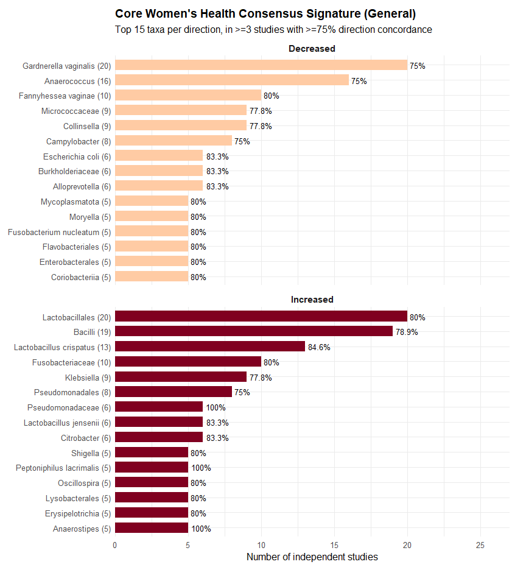

```r
core.sig %>%
  group_by(majority_dir) %>%
  slice_max(n_studies, n = 15, with_ties = FALSE) %>%
  ungroup() %>%
  mutate(
    direction_label = if_else(majority_dir == "increased",
                               "Increased", "Decreased"),
    taxon_label = paste0(str_wrap(taxon, width = 28), " (", n_studies, ")")
  ) %>%
  ggplot(aes(x = reorder(taxon_label, n_studies), y = n_studies, fill = direction_label)) +
  geom_col(width = 0.7) +
  geom_text(aes(label = paste0(concordance_pct, "%")), hjust = -0.15, size = 3.3) +
  coord_flip(clip = "off") +
  facet_wrap(~direction_label, scales = "free_y", ncol = 1) +
  scale_fill_manual(values = c("Increased" = "#800020", "Decreased" = "#FFCBA4")) +
  scale_y_continuous(expand = expansion(mult = c(0, 0.35))) +
  labs(
    title = "Core Women's Health Consensus Signature (General)",
    subtitle = "Top 15 taxa per direction, in >=3 studies with >=75% direction concordance",
    x = NULL, y = "Number of independent studies", fill = NULL
  ) +
  theme_minimal(base_size = 12) +
  theme(
    legend.position = "none",
    plot.title = element_text(face = "bold"),
    axis.text.y = element_text(size = 10, lineheight = 0.9),
    strip.text = element_text(size = 11, face = "bold"),
    plot.margin = margin(t = 10, r = 20, b = 10, l = 10)
  )
```

```r
knitr::kable(core.sig)
```

| taxon | n_studies | n_increased | n_decreased | concordance_pct | majority_dir |
| --- | --- | --- | --- | --- | --- |
| Gardnerella vaginalis | 20 | 7 | 15 | 75.0 | decreased |
| Anaerococcus | 16 | 6 | 12 | 75.0 | decreased |
| Fannyhessea vaginae | 10 | 2 | 8 | 80.0 | decreased |
| Collinsella | 9 | 2 | 7 | 77.8 | decreased |
| Micrococcaceae | 9 | 3 | 7 | 77.8 | decreased |
| Campylobacter | 8 | 2 | 6 | 75.0 | decreased |
| Alloprevotella | 6 | 1 | 5 | 83.3 | decreased |
| Burkholderiaceae | 6 | 3 | 5 | 83.3 | decreased |
| Escherichia coli | 6 | 1 | 5 | 83.3 | decreased |
| Coriobacteriia | 5 | 1 | 4 | 80.0 | decreased |
| Enterobacterales | 5 | 1 | 4 | 80.0 | decreased |
| Flavobacteriales | 5 | 1 | 4 | 80.0 | decreased |
| Fusobacterium nucleatum | 5 | 2 | 4 | 80.0 | decreased |
| Moryella | 5 | 1 | 4 | 80.0 | decreased |
| Mycoplasmatota | 5 | 1 | 4 | 80.0 | decreased |
| Sneathia sanguinegens | 5 | 1 | 4 | 80.0 | decreased |
| Bacteroides ovatus | 4 | 0 | 4 | 100.0 | decreased |
| Streptococcus mitis | 4 | 0 | 4 | 100.0 | decreased |
| Actinomycetes | 4 | 1 | 3 | 75.0 | decreased |
| Azotobacter group | 4 | 2 | 3 | 75.0 | decreased |
| Bifidobacterium pseudocatenulatum | 4 | 1 | 3 | 75.0 | decreased |
| Faecalibacterium prausnitzii | 4 | 1 | 3 | 75.0 | decreased |
| Gallicola | 4 | 1 | 3 | 75.0 | decreased |
| Gemmiger | 4 | 1 | 3 | 75.0 | decreased |
| Massilia | 4 | 1 | 3 | 75.0 | decreased |
| Mollicutes | 4 | 1 | 3 | 75.0 | decreased |
| Oxalobacteraceae | 4 | 1 | 3 | 75.0 | decreased |
| Ruminococcaceae bacterium UCG-005 | 4 | 1 | 3 | 75.0 | decreased |
| Shuttleworthella | 4 | 2 | 3 | 75.0 | decreased |
| Streptococcus anginosus | 4 | 2 | 3 | 75.0 | decreased |
| Veillonella montpellierensis | 4 | 1 | 3 | 75.0 | decreased |
| Alloprevotella tannerae | 3 | 0 | 3 | 100.0 | decreased |
| Anaerococcus sp. | 3 | 0 | 3 | 100.0 | decreased |
| Arcanobacterium | 3 | 0 | 3 | 100.0 | decreased |
| Bacteroides thetaiotaomicron | 3 | 0 | 3 | 100.0 | decreased |
| Flavobacteriia | 3 | 0 | 3 | 100.0 | decreased |
| Mogibacterium | 3 | 0 | 3 | 100.0 | decreased |
| Mycoplasmatales | 3 | 0 | 3 | 100.0 | decreased |
| Peptoniphilaceae | 3 | 0 | 3 | 100.0 | decreased |
| Peptoniphilus sp. | 3 | 0 | 3 | 100.0 | decreased |
| Prevotella sp. | 3 | 0 | 3 | 100.0 | decreased |
| Rhizobiaceae | 3 | 1 | 3 | 100.0 | decreased |
| Rothia mucilaginosa | 3 | 0 | 3 | 100.0 | decreased |
| Shewanella | 3 | 0 | 3 | 100.0 | decreased |
| Sphingomonas leidyi | 3 | 1 | 3 | 100.0 | decreased |
| Streptococcus pneumoniae | 3 | 0 | 3 | 100.0 | decreased |
| Veillonella dispar | 3 | 0 | 3 | 100.0 | decreased |
| uncultured Lachnospiraceae bacterium | 3 | 0 | 3 | 100.0 | decreased |
| Lactobacillales | 20 | 16 | 5 | 80.0 | increased |
| Bacilli | 19 | 15 | 5 | 78.9 | increased |
| Lactobacillus crispatus | 13 | 11 | 5 | 84.6 | increased |
| Fusobacteriaceae | 10 | 8 | 4 | 80.0 | increased |
| Klebsiella | 9 | 7 | 2 | 77.8 | increased |
| Pseudomonadales | 8 | 6 | 3 | 75.0 | increased |
| Pseudomonadaceae | 6 | 6 | 1 | 100.0 | increased |
| Citrobacter | 6 | 5 | 1 | 83.3 | increased |
| Lactobacillus jensenii | 6 | 5 | 1 | 83.3 | increased |
| Anaerostipes | 5 | 5 | 0 | 100.0 | increased |
| Peptoniphilus lacrimalis | 5 | 5 | 0 | 100.0 | increased |
| Erysipelotrichia | 5 | 4 | 1 | 80.0 | increased |
| Lysobacterales | 5 | 4 | 1 | 80.0 | increased |
| Oscillospira | 5 | 4 | 1 | 80.0 | increased |
| Shigella | 5 | 4 | 1 | 80.0 | increased |
| Agrobacterium | 4 | 3 | 1 | 75.0 | increased |
| Anaerococcus vaginalis | 4 | 3 | 1 | 75.0 | increased |
| Arthrobacter | 4 | 3 | 2 | 75.0 | increased |
| Catenibacterium | 4 | 3 | 2 | 75.0 | increased |
| Christensenellaceae | 4 | 3 | 1 | 75.0 | increased |
| Collinsella aerofaciens | 4 | 3 | 1 | 75.0 | increased |
| Hoylesella buccalis | 4 | 3 | 2 | 75.0 | increased |
| Limosilactobacillus vaginalis | 4 | 3 | 1 | 75.0 | increased |
| Phyllobacterium | 4 | 3 | 2 | 75.0 | increased |
| Prevotella disiens | 4 | 3 | 2 | 75.0 | increased |
| Vagococcus | 4 | 3 | 1 | 75.0 | increased |
| Acidobacteriota | 3 | 3 | 0 | 100.0 | increased |
| Bifidobacterium dentium | 3 | 3 | 0 | 100.0 | increased |
| Bradyrhizobium | 3 | 3 | 0 | 100.0 | increased |
| Brevundimonas | 3 | 3 | 0 | 100.0 | increased |
| Marvinbryantia | 3 | 3 | 0 | 100.0 | increased |
| Prevotella corporis | 3 | 3 | 0 | 100.0 | increased |

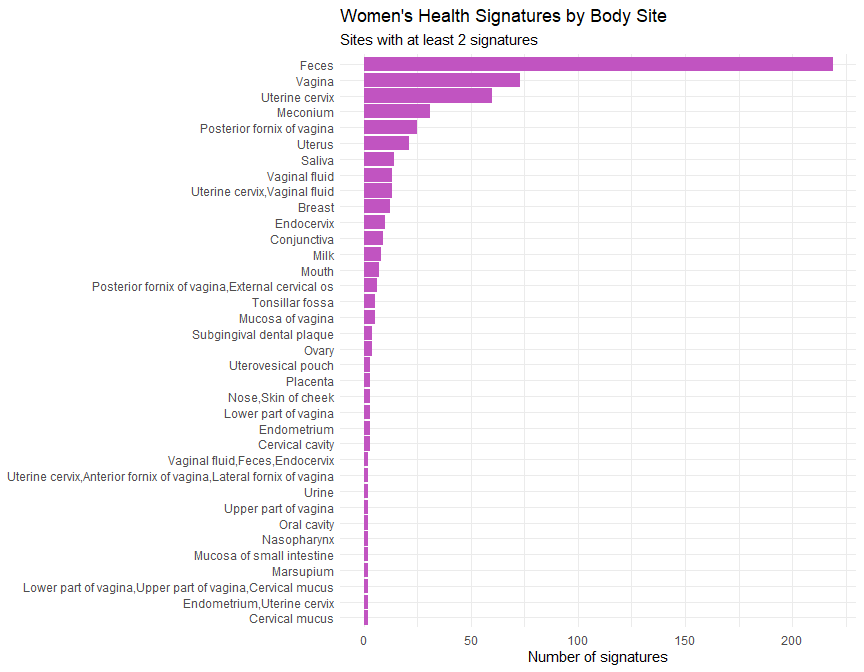

```r
womens_health_dat %>%
  count(`Body site`, sort = TRUE) %>%
  filter(n >= 2) %>%
  ggplot(aes(x = reorder(`Body site`, n), y = n)) +
  geom_col(fill = "#C154C1") +
  coord_flip() +
  labs(
    title = "Women's Health Signatures by Body Site",
    subtitle = "Sites with at least 2 signatures",
    x = NULL, y = "Number of signatures"
  ) +
  theme_minimal(base_size = 11)
```

# WMS vs 16S concordance

```r
dir.by.platform <- taxon.long %>%
  filter(`Sequencing type` %in% c("WMS", "16S")) %>%
  distinct(PMID, taxon, direction, `Sequencing type`) %>%
  count(taxon, `Sequencing type`, direction, name = "n_studies") %>%
  group_by(taxon, `Sequencing type`) %>%
  slice_max(n_studies, n = 1, with_ties = FALSE) %>%
  ungroup() %>%
  select(taxon, `Sequencing type`, majority_dir = direction)

platform.compare <- dir.by.platform %>%
  pivot_wider(names_from = `Sequencing type`, values_from = majority_dir) %>%
  filter(!is.na(WMS), !is.na(`16S`)) %>%
  rename(dir_WMS = WMS, dir_16S = `16S`) %>%
  mutate(agree = dir_WMS == dir_16S)

nrow(platform.compare)
```

```
## [1] 177
```

```r
sum(platform.compare$agree)
```

```
## [1] 76
```

```r
round(100 * mean(platform.compare$agree), 1)
```

```
## [1] 42.9
```

```r
knitr::kable(platform.compare)
```

| taxon | dir_WMS | dir_16S | agree |
| --- | --- | --- | --- |
| Achromobacter | decreased | decreased | TRUE |
| Acidobacteriota | increased | increased | TRUE |
| Actinomyces | increased | decreased | FALSE |
| Actinomycetaceae | increased | decreased | FALSE |
| Actinomycetales | increased | decreased | FALSE |
| Actinomycetes | increased | decreased | FALSE |
| Actinomycetota | increased | increased | TRUE |
| Aerococcaceae | increased | decreased | FALSE |
| Aerococcus | decreased | increased | FALSE |
| Aerococcus christensenii | decreased | decreased | TRUE |
| Agathobacter rectalis | increased | decreased | FALSE |
| Akkermansia | increased | decreased | FALSE |
| Akkermansia muciniphila | increased | decreased | FALSE |
| Alcaligenaceae | increased | increased | TRUE |
| Alistipes | decreased | increased | FALSE |
| Alistipes indistinctus | increased | decreased | FALSE |
| Alistipes massiliensis | increased | decreased | FALSE |
| Alistipes shahii | decreased | decreased | TRUE |
| Alkaliphilus | decreased | decreased | TRUE |
| Alloprevotella | increased | decreased | FALSE |
| Alloprevotella tannerae | decreased | decreased | TRUE |
| Anaerobutyricum hallii | increased | increased | TRUE |
| Anaerococcus obesiensis | increased | increased | TRUE |
| Anaerococcus vaginalis | increased | increased | TRUE |
| Anaerotruncus | increased | decreased | FALSE |
| Arcobacter | increased | decreased | FALSE |
| Atopobium | increased | decreased | FALSE |
| Bacillota | increased | increased | TRUE |
| Bacteroidales | increased | decreased | FALSE |
| Bacteroides | decreased | increased | FALSE |

[output cut: 147 more lines]

Note the much smaller WMS sample here (44 signatures total, vs. hundreds of 16S) compared to the CRC analysis - this comparison is real but less statistically powered than its CRC counterpart, and should be presented with that caveat.

# Taxon enrichment analysis

```r
n.universe <- n_distinct(taxon.long$taxon)
n.sigs     <- length(sigs.womens_health)

enrichment.df <- taxon.freq %>%
  distinct(taxon, total_studies) %>%
  mutate(
    observed         = total_studies,
    expected         = n.sigs / n.universe,
    enrichment_ratio = observed / expected,
    log2_enrichment  = log2(enrichment_ratio),
    p_value = purrr::map_dbl(observed, ~ binom.test(
      x = .x, n = n.sigs, p = 1 / n.universe, alternative = "greater"
    )$p.value),
    p_adj = p.adjust(p_value, method = "BH")
  ) %>%
  arrange(p_adj, desc(log2_enrichment))

sum(enrichment.df$p_adj < 0.05)
```

```
## [1] 321
```

```r
knitr::kable(head(enrichment.df, 15))
```

| taxon | total_studies | observed | expected | enrichment_ratio | log2_enrichment | p_value | p_adj |
| --- | --- | --- | --- | --- | --- | --- | --- |
| Lactobacillus | 52 | 52 | 0.4919643 | 105.69873 | 6.723814 | 0 | 0 |
| Streptococcus | 41 | 41 | 0.4919643 | 83.33938 | 6.380927 | 0 | 0 |
| Prevotella | 35 | 35 | 0.4919643 | 71.14338 | 6.152658 | 0 | 0 |
| Actinomycetota | 31 | 31 | 0.4919643 | 63.01270 | 5.977571 | 0 | 0 |
| Bacteroides | 31 | 31 | 0.4919643 | 63.01270 | 5.977571 | 0 | 0 |
| Lactobacillaceae | 31 | 31 | 0.4919643 | 63.01270 | 5.977571 | 0 | 0 |
| Staphylococcus | 31 | 31 | 0.4919643 | 63.01270 | 5.977571 | 0 | 0 |
| Bacillota | 29 | 29 | 0.4919643 | 58.94737 | 5.881355 | 0 | 0 |
| Bifidobacterium | 28 | 28 | 0.4919643 | 56.91470 | 5.830729 | 0 | 0 |
| Bacteroidales | 27 | 27 | 0.4919643 | 54.88203 | 5.778262 | 0 | 0 |
| Eubacteriales | 27 | 27 | 0.4919643 | 54.88203 | 5.778262 | 0 | 0 |
| Bacteroidia | 26 | 26 | 0.4919643 | 52.84936 | 5.723814 | 0 | 0 |
| Dialister | 26 | 26 | 0.4919643 | 52.84936 | 5.723814 | 0 | 0 |
| Veillonella | 25 | 25 | 0.4919643 | 50.81670 | 5.667231 | 0 | 0 |
| Gardnerella | 24 | 24 | 0.4919643 | 48.78403 | 5.608337 | 0 | 0 |

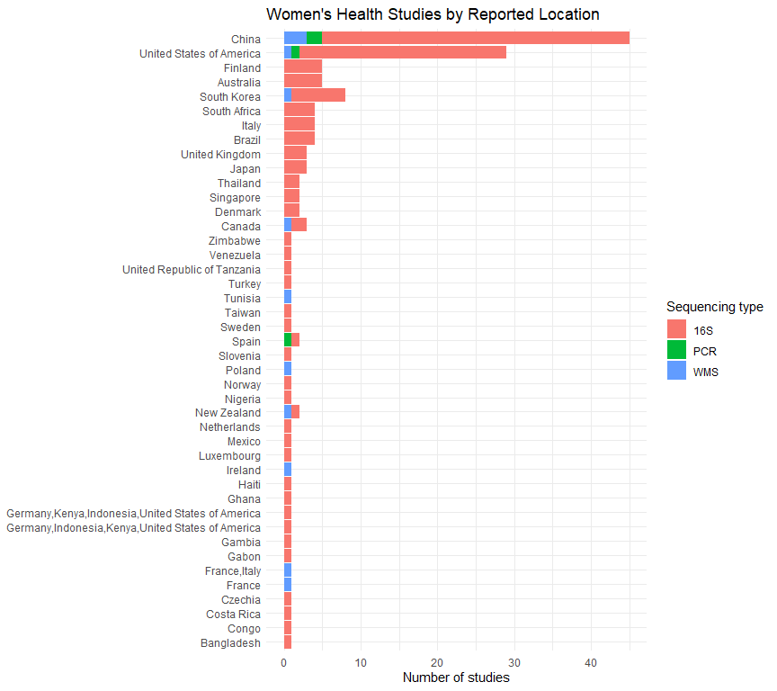

```r
womens_health_dat %>%
  distinct(PMID, `Location of subjects`, `Sequencing type`) %>%
  count(`Location of subjects`, `Sequencing type`) %>%
  ggplot(aes(x = reorder(`Location of subjects`, n), y = n, fill = `Sequencing type`)) +
  geom_col() +
  coord_flip() +
  labs(
    title = "Women's Health Studies by Reported Location",
    x = NULL, y = "Number of studies"
  ) +
  theme_minimal(base_size = 11)
```

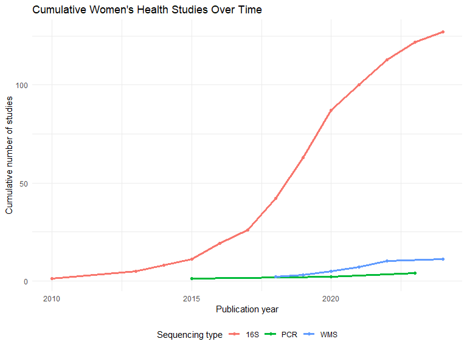

```r
womens_health_dat %>%
  distinct(PMID, Year, `Sequencing type`) %>%
  count(Year, `Sequencing type`) %>%
  filter(!is.na(Year)) %>%
  group_by(`Sequencing type`) %>%
  arrange(Year) %>%
  mutate(cumulative_n = cumsum(n)) %>%
  ungroup() %>%
  ggplot(aes(x = Year, y = cumulative_n, color = `Sequencing type`)) +
  geom_line(linewidth = 1.2) +
  geom_point() +
  labs(
    title = "Cumulative Women's Health Studies Over Time",
    x = "Publication year", y = "Cumulative number of studies", color = "Sequencing type"
  ) +
  theme_minimal(base_size = 11) +
  theme(legend.position = "bottom")
```

# Monte Carlo critical N

```r
siglengths <- lengths(womens_health_dat$`MetaPhlAn taxon names`)

criticalN <- getCriticalN(
  relevant.sigs = womens_health_dat$`MetaPhlAn taxon names`,
  siglengths = siglengths
)

criticalN
```

```
## $critical_n
## 95%
##  75
##
## $ci_lower
## 2.5%
##   74
##
## $ci_upper
## 97.5%
##    76
##
## $simulated_values
##    [1] 61 72 66 68 59 52 71 57 52 77 61 60 68 52 61 57 53 60 73 76 68 65 48 71
##   [25] 77 60 60 58 70 54 57 48 75 68 68 58 70 73 62 68 67 66 62 58 50 67 58 62
```

[output cut: 46 more lines]

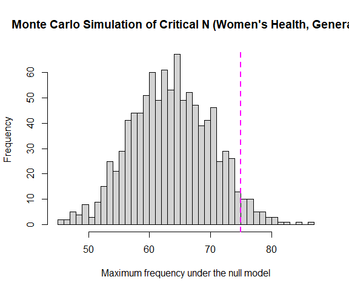

```r
hist(
  criticalN$simulated_values,
  breaks = 30,
  main = "Monte Carlo Simulation of Critical N (Women's Health, General)",
  xlab = "Maximum frequency under the null model"
)

abline(
  v = criticalN$critical_n,
  col = "#FF00FF",
  lwd = 2,
  lty = 2
)
```

# Signature similarity

```r
allsigs <- bugsigdbr::getSignatures(womens_health_dat, tax.id.type = "taxname")

allsigs <- allsigs[sapply(allsigs, length) > 1]

length(allsigs)
```

```
## [1] 441
```

```r
mydists <- BugSigDBStats::calcPairwiseOverlaps(allsigs)

dim(mydists)
```

```
## [1] 14474     8
```

```r
jmat <- BugSigDBStats::calcJaccardSimilarity(allsigs)

row_labels <- sub("^bsdb:", "PMID", sub("_.*$", "", rownames(jmat)))
col_labels <- sub("^bsdb:", "PMID", sub("_.*$", "", colnames(jmat)))
```

# Heatmap

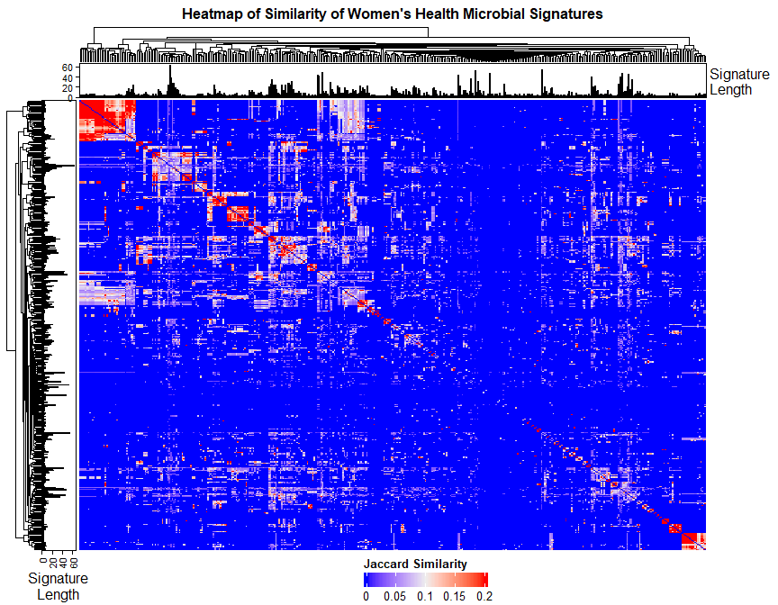

```r
library(grid)
library(ComplexHeatmap)

siglengths <- sapply(allsigs, length)

# Set standard, crisp base font sizes
ha <- HeatmapAnnotation(
  `Signature\nLength` = anno_barplot(siglengths, gp = gpar(fill = "steelblue"))
)

hr <- rowAnnotation(
  `Signature\nLength` = anno_barplot(siglengths, gp = gpar(fill = "steelblue"))
)

hm <- Heatmap(
  jmat,
  top_annotation = ha,
  left_annotation = hr,
  show_row_names = FALSE,
  show_column_names = FALSE,
  column_title = "Heatmap of Similarity of Women's Health Microbial Signatures",
  column_title_gp = gpar(fontsize = 12, fontface = "bold"),
  heatmap_legend_param = list(title = "Jaccard Similarity", direction = "horizontal")
)

# Draw cleanly directly to your HTML page output
draw(hm, heatmap_legend_side = "bottom")
```

```r
# Force turn off any weird existing devices
dev.off()
```

```r
# Open clean canvas with safe, static dimensions
png(
  filename = "WomensHealth_heatmap.png",
  width = 12,
  height = 10,
  units = "in",
  res = 300
)

# Draw the heatmap inside the device
draw(
  hm,
  heatmap_legend_side = "bottom",
  annotation_legend_side = "right",
  padding = unit(c(2, 2, 2, 10), "mm")
)

# Crucial: turn off the device to save the file cleanly
dev.off()
```

Given the heterogeneity already observed in the taxon frequency table (vaginal-health taxa vs. gut-health taxa), this heatmap is expected to reveal distinct clusters of studies rather than one homogeneous signature - likely separating along body-site/condition lines (vaginal/cervical studies vs. fecal/metabolic studies) rather than a single unified women’s-health signature. This heterogeneity is the core rationale for the four focused sub-analyses that follow this General analysis.

# Dendrogram

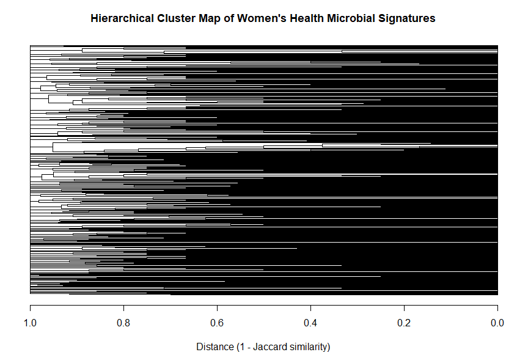

```r
hc <- hclust(as.dist(1 - jmat))
dend <- as.dendrogram(hc)

# Standard margin structure
par(mar = c(4, 1, 3, 1))

plot(
  dend,
  horiz = TRUE,
  leaflab = "none",
  main = "Hierarchical Cluster Map of Women's Health Microbial Signatures",
  xlab = "Distance (1 - Jaccard similarity)",
  cex.main = 1.1
)
```

[output not shown]